# 2. 最小编辑距离

Natural Language Processing I

2. 最小编辑距离

WU Xiaokun 吴晓堃

xkun.wu [at] gmail

2022/03/11

# 定义

## 用例：拼写

拼写校正

- 用户写“graffe”，下面那个正确？
  - graf, graft, grail, giraffe

中文：拼音输入法

```
严谨作弊？
严禁作弊！
```

模糊搜索：返回相近的搜索

## 用例：计算生物学

- RNA 序列匹配：

```
AGGCTATCACCTGACCTCCAGGCCGATGCCC
TAGCTATCACGACCGCGGTCGATTTGCCCGAC
```

```
-AGGCTATCACCTGACCTCCAGGCCGA--TGCCC---
TAG-CTATCAC--GACCGC--GGTCGATTTGCCCGAC
```

## 用例：共指

**共指 coreference**：表述之间是否指向同一个实体

```
中国
中华人民共和国
大中华地区
中國 (佛教) ：釋迦牟尼出生地
震旦：漢傳佛教經典中，對古代中國的稱呼
阮朝：越南阮朝朝廷在國內有時也自稱為「中國」
China, la Chine, ...
```

其他应用：机器翻译，信息提取，语言识别

## 度量相似度

从计算的角度讲，很多NLP任务的核心是度量字符串的**相似度**

- 如何度量相似度？观察打字与修改
  - 字符串是由编辑操作构造的
  - 每一步只涉及一个字符

例如最简单的拉丁字母序列

```
intention
execution
```

## 编辑距离

从计算的角度讲，很多NLP任务的核心是度量字符串的**相似度**

- 如何度量相似度？观察打字与修改
- 例如最简单的拉丁字母序列

```
intention
execution
```

**编辑距离 edit distance**：编辑操作的数量

- 插入字符
- 删除字符
- 替换字符

## 对齐可视化

**对齐 alignment**：将尽可能多的相同字符对应起来

- 插入、删除字符时插入空字符`*`

| d | s | s |  | i | s |  |  |  |  |
| --- | --- | --- | --- | --- | --- | --- | --- | --- | --- |
| I | N | T | E | * | N | T | I | O | N |
| * | E | X | E | C | U | T | I | O | N |

- 编辑距离：简单数一下编辑操作

**最小编辑距离**：对齐最多的字母；最少的编辑操作

## 编辑成本

**Levenshtein 距离**：字符串之间的加权编辑距离

- 每种操作的“成本”可以不一样

| d | s | s |  | i | s |  |  |  |  |
| --- | --- | --- | --- | --- | --- | --- | --- | --- | --- |
| I | N | T | E | * | N | T | I | O | N |
| * | E | X | E | C | U | T | I | O | N |

- 等权重：$5$
- 替换成本翻倍：$8$
  - 替换可以看成：删除+插入

## MED 应用

评测机器翻译、语音识别

|  | d | d |  |  |  | i | i |
| --- | --- | --- | --- | --- | --- | --- | --- |
| He | to | reporters | introduced | main | content | * | * |
| He | * | * | introduced | main | content | to | reporters |
| 他 | 向 | 记者 | 介绍了 | 主要 | 内容 | * | * |

命名实体识别、共指消解

```
中华人民共和国 简称 中国
```

## 如何计算MED？

简单搜索：搜索空间随字符长度指数级增长

- `D`：$1$
- `I`：$26$
- `S`：$26$，或禁止替换操作

大量路径通往相同字符串

| d | s | s |  | i | s |  |  |  |  |
| --- | --- | --- | --- | --- | --- | --- | --- | --- | --- |
| I | N | T | E | * | N | T | I | O | N |
| * | E | X | E | C | U | T | I | O | N |

| s | d | s |  | s | i |  |  |  |  |
| --- | --- | --- | --- | --- | --- | --- | --- | --- | --- |
| I | N | T | E | N | * | T | I | O | N |
| E | * | X | E | C | U | T | I | O | N |

- 不需要记住所有路径
- 只需要其中一条最短路径

听起来像是动态规划的思想？

# 计算MED

## 问题定义

字符串：

- $x = x_1x_2..x_n$
- $y = y_1y_2..y_m$

子串：

- $x[1..i] = x_1x_2..x_i$
- $y[1..j] = y_1y_2..y_j$

距离函数：

- 字串距离：$D(i,j) = MED(x[1..i], y[1..j])$
- 编辑距离：$D(n,m)$

## 动态规划

**动态规划 dynamic programming**：基于表格查找

- 将问题拆解成一系列子问题
- 自底向上合并子问题的解

**Bellman 方程**：递推关系 recurrence relation

$$D(i, j) = \left\{ \begin{array}{ll}
j \delta & \text{if}\ i = 0 \\
i \delta & \text{if}\ j = 0 \\
\min \{
\alpha_{x_i,y_j} + D(i-1,j-1),
\delta + D(i-1,j),
\delta + D(i,j-1)
\} & \text{otherwise} \\
\end{array}\right.$$

- 插入、删除花费：$\delta = 1$；替换花费：$\alpha_{pq} = \{0, 2\}$

## MED表：初始化

| N | 9 |  |  |  |  |  |  |  |  |  |
| --- | --- | --- | --- | --- | --- | --- | --- | --- | --- | --- |
| O | 8 |  |  |  |  |  |  |  |  |  |
| I | 7 |  |  |  |  |  |  |  |  |  |
| T | 6 |  |  |  |  |  |  |  |  |  |
| N | 5 |  |  |  |  |  |  |  |  |  |
| E | 4 |  |  |  |  |  |  |  |  |  |
| T | 3 |  |  |  |  |  |  |  |  |  |
| N | 2 |  |  |  |  |  |  |  |  |  |
| I | 1 |  |  |  |  |  |  |  |  |  |
| # | 0 | 1 | 2 | 3 | 4 | 5 | 6 | 7 | 8 | 9 |
|  | # | E | X | E | C | U | T | I | O | N |

## MED表：填表 I

| I | 1 | 2 | 3 | 4 | 5 | 6 | 7 | 6 | 7 | 8 |
| --- | --- | --- | --- | --- | --- | --- | --- | --- | --- | --- |
| # | 0 | 1 | 2 | 3 | 4 | 5 | 6 | 7 | 8 | 9 |
|  | # | E | X | E | C | U | T | I | O | N |

| i | i | i | i | i | i |  |  |  |
| --- | --- | --- | --- | --- | --- | --- | --- | --- |
| * | * | * | * | * | * | I |  |  |
| E | X | E | C | U | T | I |  |  |

## MED表：填表 E

| E | 4 | 3 | 4 | 5 | 6 | 7 | 8 | 9 | 10 | 9 |
| --- | --- | --- | --- | --- | --- | --- | --- | --- | --- | --- |
| T | 3 | 4 | 5 | 6 | 7 | 8 | 7 | 8 | 9 | 8 |
| N | 2 | 3 | 4 | 5 | 6 | 7 | 8 | 7 | 8 | 7 |
| I | 1 | 2 | 3 | 4 | 5 | 6 | 7 | 6 | 7 | 8 |
| # | 0 | 1 | 2 | 3 | 4 | 5 | 6 | 7 | 8 | 9 |
|  | # | E | X | E | C | U | T | I | O | N |

| d | d | d |  |  |  |  |  |  |
| --- | --- | --- | --- | --- | --- | --- | --- | --- |
| I | N | T | E |  |  |  |  |  |
| * | * | * | E |  |  |  |  |  |

## MED表：完整版

| N | 9 | 8 | 9 | 10 | 11 | 12 | 11 | 10 | 9 | 8 |
| --- | --- | --- | --- | --- | --- | --- | --- | --- | --- | --- |
| O | 8 | 7 | 8 | 9 | 10 | 11 | 10 | 9 | 8 | 9 |
| I | 7 | 6 | 7 | 8 | 9 | 10 | 9 | 8 | 9 | 10 |
| T | 6 | 5 | 6 | 7 | 8 | 9 | 8 | 9 | 10 | 11 |
| N | 5 | 4 | 5 | 6 | 7 | 8 | 9 | 10 | 11 | 10 |
| E | 4 | 3 | 4 | 5 | 6 | 7 | 8 | 9 | 10 | 9 |
| T | 3 | 4 | 5 | 6 | 7 | 8 | 7 | 8 | 9 | 8 |
| N | 2 | 3 | 4 | 5 | 6 | 7 | 8 | 7 | 8 | 7 |
| I | 1 | 2 | 3 | 4 | 5 | 6 | 7 | 6 | 7 | 8 |
| # | 0 | 1 | 2 | 3 | 4 | 5 | 6 | 7 | 8 | 9 |
|  | # | E | X | E | C | U | T | I | O | N |

# 回溯

## 对齐方案

注意：任务通常并不仅是计算编辑距离

- 大多数情况需要字符对齐的**具体方案**

| N | 9 | 8 | 9 | 10 | 11 | 12 | 11 | 10 | 9 | 8 |
| --- | --- | --- | --- | --- | --- | --- | --- | --- | --- | --- |
| O | 8 | 7 | 8 | 9 | 10 | 11 | 10 | 9 | 8 | 9 |
| I | 7 | 6 | 7 | 8 | 9 | 10 | 9 | 8 | 9 | 10 |
| T | 6 | 5 | 6 | 7 | 8 | 9 | 8 | 9 | 10 | 11 |
| N | 5 | 4 | 5 | 6 | 7 | 8 | 9 | 10 | 11 | 10 |
| E | 4 | 3 | 4 | 5 | 6 | 7 | 8 | 9 | 10 | 9 |
| T | 3 | 4 | 5 | 6 | 7 | 8 | 7 | 8 | 9 | 8 |
| N | 2 | 3 | 4 | 5 | 6 | 7 | 8 | 7 | 8 | 7 |
| I | 1 | 2 | 3 | 4 | 5 | 6 | 7 | 6 | 7 | 8 |
| # | 0 | 1 | 2 | 3 | 4 | 5 | 6 | 7 | 8 | 9 |
|  | # | E | X | E | C | U | T | I | O | N |

| s | d | s |  | s | i |  |  |  |  |
| --- | --- | --- | --- | --- | --- | --- | --- | --- | --- |
| I | N | T | E | N | * | T | I | O | N |
| E | * | X | E | C | U | T | I | O | N |

## 回溯法

**回溯法 backtrace**：在计算每个表格时，记录路径来源

- 算法结束后，从终点回溯到起点
- 注意：路径不唯一，取决于代码执行顺序
  - 但关键节点一定会通过

| E | 4 | 3 | 4 | 5 | 6 | 7 | 8 | 9 | 10 | 9 |
| --- | --- | --- | --- | --- | --- | --- | --- | --- | --- | --- |
| T | 3 | 4 | 5 | 6 | 7 | 8 | 7 | 8 | 9 | 8 |
| N | 2 | 3 | 4 | 5 | 6 | 7 | 8 | 7 | 8 | 7 |
| I | 1 | 2 | 3 | 4 | 5 | 6 | 7 | 6 | 7 | 8 |
| # | 0 | 1 | 2 | 3 | 4 | 5 | 6 | 7 | 8 | 9 |
|  | # | E | X | E | C | U | T | I | O | N |

## MED回溯表

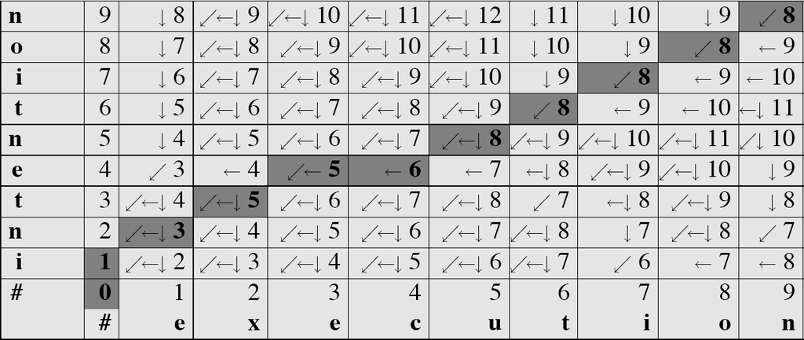